# HW04: Calibration of models.

Authors:

- Rubén Baixauli Ramos
- Óscar Giménez Pascual
- Mario Martínez Escrivá

Please use latex for the derivations. Alternatively, insert a scanned image of the derivations, as it is here done with the Alan Turing [https://www.turing.org.uk/] picture.

[figure not shown]

```python
import numpy as np
import pandas as pd

import matplotlib.pyplot as plt
import my_option_pricing as pricing

import scipy.stats as stats

from scipy.stats import norm, lognorm
from numpy.random import default_rng

from pandas.plotting import autocorrelation_plot
from scipy.stats import norm, probplot, t
from scipy.optimize import minimize

from tools_qfb import (
    compare_histogram_pdf,
    qqplot,
    plot_residual_diagnostics
)

from stochastic_processes import simulate_geometric_brownian_motion
from my_time_series import (
    simulate_AR,
    residuals_AR,
    fit_AR_LS,
    fit_AR_ML_gaussian_noise,
    fit_AR_ML_student_t_noise,
    simulate_ARMA_GARCH,
    residuals_ARMA_GARCH,
    fit_AR_GARCH_ML_gaussian_noise,
    fit_AR_GARCH_ML_student_t_noise,
    tests_gaussian_white_noise,
    t_transient,
)

from model_calibration import fit_pdf_ML


%load_ext autoreload
%autoreload 2
```

## Exercise 1: AR processes

The evolution of an AR(p) processs is described by a difference equation of order $p$ that is the sum of two terms: a linear model for the deterministic part and additive noise for the stochastic one: $$ X_t = \phi_0 + \sum_{\tau=1}^p \phi_{\tau} X_{t- \tau} + u_t, \quad t = p+1, p+2, \ldots, $$ where $\left\{u_t \right\}_{t=p+1}^T$ is independent identically distributed noise, which is also independent of $X_{t-\tau}$ for all $\tau > 0$.

To make a simulation of the process one needs $p$ initial conditions $\left\{X_t \right\}_{t=1}^p$.

Note that if the parameters $\phi_0, \boldsymbol{\phi}^T = \left(\phi_1, \phi_2, \ldots, \phi_p\right)$ are known, the value of $X_t$ can be predicted from the past values of the series using the linear model $$ \hat{X}_t = \phi_0 + \sum_{\tau=1}^p \phi_{\tau} X_{t- \tau}. $$ The error of this linear predictor is $$ u_t = X_t - \left(\phi_0 + \sum_{\tau=1}^p \phi_{\tau} X_{t- \tau} \right). $$ Since the values $\left\{u_t \right\}_{t=p1}^T $ correspond to the term in $X_t$ that cannot be predicted from the past values of the time series (it is independent of them), they are known as the innovations or the residuals of the model.

Assume that the distribution of the innovations is characterized by a probability density $$ u_t \sim \text{pdf}\left(u; \boldsymbol{\gamma}\right), $$ which depends on the vector of parameters $\boldsymbol{\gamma}$.

#### Fit of an AR(p) process: Least squares and maximum likelihood.

Consider a time series $$ \left\{X_t \right\}_{t=1}^T = \left(X_1, X_2, \ldots, X_T \right). $$ We wish to find the parameters of the AR(p) process that best fit these data. To this end, we can apply two different methods:

1. **Least squares**: The parameters of the deterministic part of the model are obtained by minimizing the mean squared error. $$ \begin{aligned} \phi_0^{[LS]}, \boldsymbol{\phi}^{[LS]} & = \arg \min_{\phi_0, \boldsymbol{\phi}} \left[ \frac{1}{T-p} \sum_{t=p+1}^T u_t^2 \right] \\ & = \arg \min_{\phi_0, \boldsymbol{\phi}} \left[ \frac{1}{T-p} \sum_{t=p+1}^T \left(X_t - \left(\phi_0 + \sum_{\tau=1}^p \phi_{\tau} X_{t- \tau} \right) \right)^2 \right]. \end{aligned} $$
2. **Maximum likelihood**: The parameters are determined by maximizing the likelihood of the model given the data. $$ \phi_0^{[ML]}, \boldsymbol{\phi}^{[ML]}, \boldsymbol{\gamma}^{[ML]} = \arg \min_{\phi_0, \boldsymbol{\phi}, \boldsymbol{\gamma}} \mathcal{L}\left(\phi_0, \boldsymbol{\phi}, \boldsymbol{\gamma}; \left\{X_t \right\}_{t=1}^T \right), $$ The likelihood function is the probability of having observed the data, assuming that the model is known $$ \begin{aligned} \mathcal{L}\left(\phi_0, \boldsymbol{\phi}, \boldsymbol{\gamma}; \left\{X_t \right\}_{t=1}^T \right) & = \text{P}\left(\left. \left\{X_t \right\}_{t=p+1}^T \right| \left\{X_{\tau}\right\}_{\tau=1}^p, \phi_0, \boldsymbol{\phi}, \boldsymbol{\gamma}\right) \\ & = \prod_{t=p+1}^T \text{P}\left(\left. X_t \right| \left\{X_{t-\tau}\right\}_{\tau=1}^p, \phi_0, \boldsymbol{\phi}, \boldsymbol{\gamma} \right) = \prod_{t=p+1}^T \text{pdf}\left(u_t; \boldsymbol{\gamma} \right). \end{aligned} $$ The probability density $\text{P}\left(\left. \left\{X_t \right\}_{t=p+1}^T \right| \left\{X_{\tau}\right\}_{\tau=1}^p, \phi_0, \boldsymbol{\phi}, \boldsymbol{\gamma}\right)$ factorizes because $$ u_t = X_t - \left(\phi_0 + \sum_{\tau=1}^p \phi_{\tau} X_{t- \tau} \right). $$ is independent identically distributed (iid) noise that is also independent of the past values of the series.

#### Exercise 1.1: Minimization of minus the log-likelihood.

Show that maximizing the likelihood is equivalent to minimizing $$ \text{minus-}\mathcal{LL}\left(\phi_0, \boldsymbol{\phi}, \boldsymbol{\gamma}; \left\{X_t \right\}_{t=1}^T \right) = - \log \left( \mathcal{L}\left(\phi_0, \boldsymbol{\phi}, \boldsymbol{\gamma}; \left\{X_t \right\}_{t=1}^T \right) \right), $$ or any postive constant times this quantity.

**Your answer goes here**

To proof that maximizing the likelihood function $\mathcal{L}$ is equivalent to minimizing the negative log-likelihood $-\log(\mathcal{L})$, or any positive constant multiplied by this quantity, we can rely on the following mathematical properties:

1. **Monotonicity of the logarithm**: The likelihood function $\mathcal{L}$ returns probability or probability density values, meaning it takes positive values ($\mathcal{L} > 0$). Since the natural logarithm function, $f(x) = \log(x)$, is strictly increasing over its entire domain ($x > 0$), any set of parameters that achieves the maximum value for $\mathcal{L}$ will be exactly the same set that achieves the maximum value for $\log(\mathcal{L})$.
2. **Equivalence between maximizing and minimizing:** In mathematical optimization theory, the problem of finding the maximum of a function is equivalent to finding the minimum of the negative of that same function. That is, $\arg \max f(x) = \arg \min (-f(x))$. Therefore, maximizing $\log(\mathcal{L})$ is mathematically identical to minimizing $-\log(\mathcal{L})$.
3. **Multiplication by a constant**: Multiplying a function to be minimized by any positive constant $C$ ($C > 0$) alters the scale or final value of the function, but it does not change the location of its minimum point. The optimal parameters we are looking for remain the same.

$$\arg \max_{\phi_0, \boldsymbol{\phi}, \boldsymbol{\gamma}} \mathcal{L}\left(\phi_0, \boldsymbol{\phi}, \boldsymbol{\gamma}; \left\{X_t \right\}_{t=1}^T \right) = \arg \max_{\phi_0, \boldsymbol{\phi}, \boldsymbol{\gamma}} \log \mathcal{L}\left(\phi_0, \boldsymbol{\phi}, \boldsymbol{\gamma}; \left\{X_t \right\}_{t=1}^T \right)$$

$$= \arg \min_{\phi_0, \boldsymbol{\phi}, \boldsymbol{\gamma}} \left( - \log \mathcal{L}\left(\phi_0, \boldsymbol{\phi}, \boldsymbol{\gamma}; \left\{X_t \right\}_{t=1}^T \right) \right) = \arg \min_{\phi_0, \boldsymbol{\phi}, \boldsymbol{\gamma}} \left( - C \log \mathcal{L}\left(\phi_0, \boldsymbol{\phi}, \boldsymbol{\gamma}; \left\{X_t \right\}_{t=1}^T \right) \right)$$

#### Exercise 1.2: Relation between maximum likelihood and least squares.

Assume a Gaussian model for the noise $$ u_t \sim \mathcal{N} \left(0, \sigma \right), \quad t = p+1, p+2, \ldots, T. $$ For this case,

1. Determine the relationship between the parameters $\phi_0^{[LS]}, \boldsymbol{\phi}^{[LS]}$ and $\phi_0^{[ML]}, \boldsymbol{\phi}^{[ML]}$. Hint: The simulations in the next cells provide an important clue to the answer.
2. How would one estimate the value of $\sigma$ in the method of least squares? Justify your answer.

**Your answer goes here.**

**1.** For a Gaussian noise model, where the residuals follow a distribution $u_t \sim \mathcal{N}(0, \sigma)$, the relationship between the parameters estimated by Least Squares (LS) and by Maximum Likelihood (ML) is that they are exactly equal:

$$\phi_0^{[ML]} = \phi_0^{[LS]} \quad \text{and} \quad \boldsymbol{\phi}^{[ML]} = \boldsymbol{\phi}^{[LS]}$$

According to the Maximum Likelihood (ML) method, the optimal parameters are found by maximizing the likelihood function $\mathcal{L}$ or, as shown in exercise 1.1, by minimizing the negative log-likelihood.

For a normal distribution $\mathcal{N}(0, \sigma)$, the probability density function (pdf) is:

$$\text{pdf}(u_t; \sigma) = \frac{1}{\sqrt{2\pi\sigma^2}} \exp\left( -\frac{u_t^2}{2\sigma^2} \right)$$

Substituting the density into the likelihood function $\mathcal{L} = \prod_{t=p+1}^T \text{pdf}(u_t; \sigma)$ and applying the natural logarithm, we obtain:

$$\log \mathcal{L} = \sum_{t=p+1}^T \log \left( \frac{1}{\sqrt{2\pi\sigma^2}} \exp\left( -\frac{u_t^2}{2\sigma^2} \right) \right)$$

Applying logarithm properties, the expression separates into:

$$\log \mathcal{L} = -\frac{T-p}{2} \log(2\pi\sigma^2) - \frac{1}{2\sigma^2} \sum_{t=p+1}^T u_t^2$$

The first term on the right is independent of the autoregressive parameters $\phi_0$ and $\boldsymbol{\phi}$. Therefore, to find the values of $\phi_0$ and $\boldsymbol{\phi}$ that maximize this log function, we must minimize the summation of the second term:

$$\arg \max_{\phi_0, \boldsymbol{\phi}} \log \mathcal{L} = \arg \min_{\phi_0, \boldsymbol{\phi}} \sum_{t=p+1}^T u_t^2$$

Recalling that $u_t$ is:

$$u_t = X_t - \left(\phi_0 + \sum_{\tau=1}^p \phi_{\tau} X_{t- \tau} \right)$$

We substitute and obtain:

$$\arg \min_{\phi_0, \boldsymbol{\phi}} \sum_{t=p+1}^T \left(X_t - \left(\phi_0 + \sum_{\tau=1}^p \phi_{\tau} X_{t- \tau} \right) \right)^2$$

This expression is mathematically identical to the objective function minimized in the Least Squares (LS) method. In conclusion, under the assumption that the errors or innovations represent a purely Gaussian white noise, the Maximum Likelihood coefficient estimates coincide fully with those of Least Squares.

**2.**

To estimate the value of $\sigma$ using the Least Squares (LS) method, we calculate the sample standard deviation of the residuals obtained after fitting the linear model:

1. **Obtaining the residuals**: In the Least Squares method, the parameters of the deterministic part ($\phi_0^{[LS]}$ and $\boldsymbol{\phi}^{[LS]}$) are obtained by minimizing the Mean Squared Error. Once these optimal parameters are calculated, we obtain the error for each time instant $t$:

$$\hat{u}_t = X_t - \left(\phi_0^{[LS]} + \sum_{\tau=1}^p \phi_{\tau}^{[LS]} X_{t- \tau} \right)$$

2. **Estimation of the variance ($\sigma^2$)**: The model assumes that the innovations are independent and identically distributed noise. In this Gaussian case, with zero mean and variance $\sigma^2$. Since the true value of the innovations dispersion is unknown, we estimate it using the dispersion of the calculated residuals $\hat{u}_t$. There are two ways to evaluate this variance from the sum of squared residuals (SSR):
- Biased estimator: It consists of averaging the sum of squared residuals using the number of evaluated observations, which is $T-p$. This directly represents the Mean Squared Error found at its minimum:

$$\hat{\sigma}^2 = \frac{1}{T-p} \sum_{t=p+1}^T \hat{u}_t^2$$

- Unbiased estimator: The average is corrected by dividing by the model's actual degrees of freedom. In this regression, $p+1$ parameters have been estimated ($\phi_0$ and the $p$ components of the vector $\boldsymbol{\phi}$). Therefore, the degrees of freedom are the $T-p$ observations minus the $p+1$ calculated parameters, that is, $T - 2p - 1$:

$$\hat{\sigma}^2_{unbiased} = \frac{1}{T - 2p - 1} \sum_{t=p+1}^T \hat{u}_t^2$$

3. **Calculation of $\sigma$**: To arrive at the estimator of $\sigma$, we simply calculate the square root of the variance estimated in the previous step:

$$\hat{\sigma} = \sqrt{ \frac{1}{T-p} \sum_{t=p+1}^T \hat{u}_t^2 } \quad \text{or} \quad \hat{\sigma}_{unbiased} = \sqrt{ \frac{1}{T - 2p - 1} \sum_{t=p+1}^T \hat{u}_t^2 }$$

### Simulation of an AR processes.

```python
# Simulation of an AR(p) process with Gaussian noise.

phi_0, phi, sigma = 0.3, [0.1, -0.8], 0.4
p = len(phi) # order of the autoregressive process.

random_number_generator = default_rng(seed=0).standard_normal

X, _ = simulate_AR(
    np.zeros(p), phi_0, phi, sigma,
    random_number_generator, n_trajectories=1, n_times=1000
)

t_stationary = int(10.0 * t_transient(phi))

X = X[0, t_stationary:] # Single trajectory in the stationary regime.
```

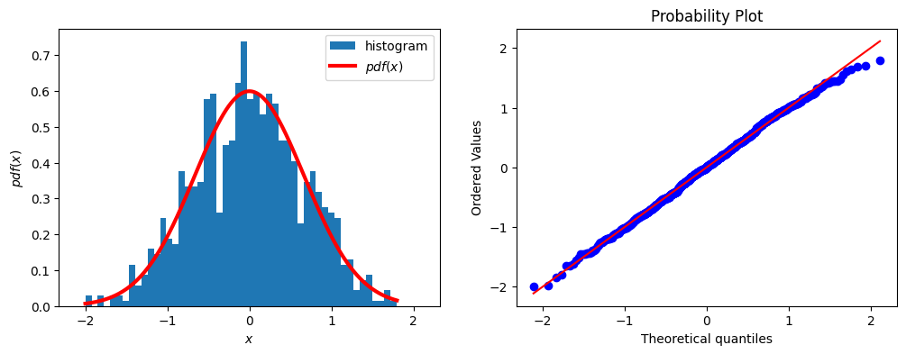

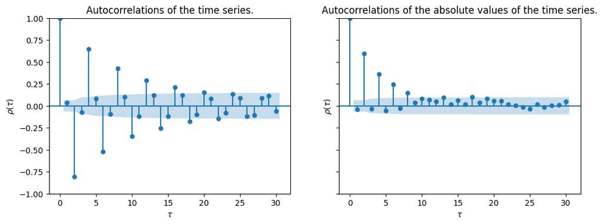

```python
# The distribution of the values of X_t is Gaussian.
# However, it exhibits linear autocorrelations.

tests_gaussian_white_noise(X - np.mean(X))
```

#### Least squares fit to an AR process

```python
# Least squares fit to AR(p) process

phi_0_LS, phi_LS, info_optimization = fit_AR_LS(X, phi_0_seed=0.0,  phi_seed=np.zeros(p))

print('Exact values:')
print(np.round(phi_0, 4), np.round(phi, 4))

print('\nLeast squares estimates:')
print(np.round(phi_0_LS, 4), np.round(phi_LS, 4))

print()
print(info_optimization)
```

```
Exact values:
0.3 [ 0.1 -0.8]

Least squares estimates:
0.2813 [ 0.0692 -0.8104]

     message: `ftol` termination condition is satisfied.
     success: True
      status: 2
         fun: [ 1.523e-01]
           x: [ 2.813e-01  6.923e-02 -8.104e-01]
        cost: 0.011596662597280325
         jac: [[ 4.284e-06  3.301e-06 -3.893e-06]]
        grad: [ 6.524e-07  5.027e-07 -5.929e-07]
  optimality: 6.52438334493191e-07
 active_mask: [ 0.000e+00  0.000e+00  0.000e+00]
        nfev: 19
        njev: 13
```

```
sigma (least squares)= 0.3902
```

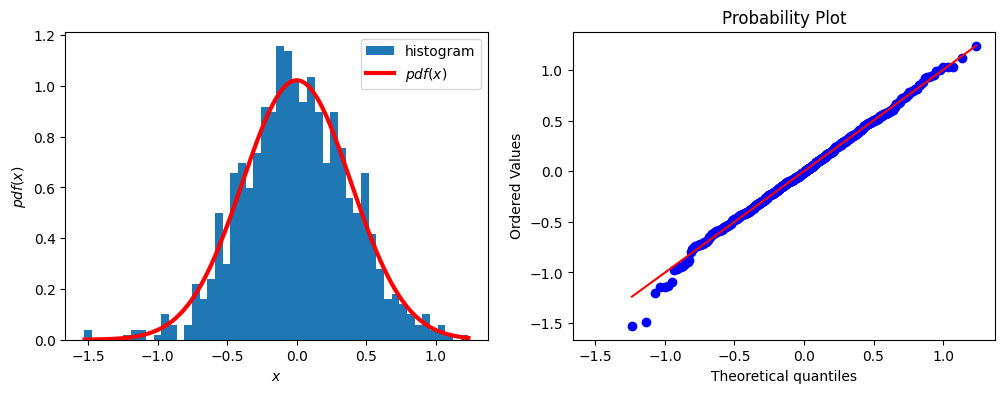

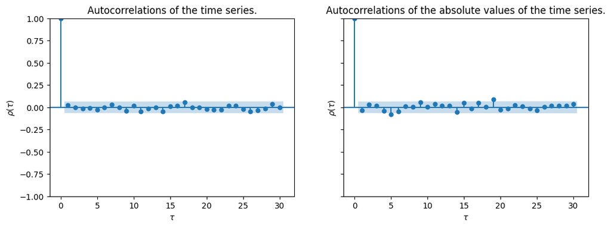

```python
# The residuals of the AR(p) model are Gaussian white noise.
u = residuals_AR(X, phi_0_LS, phi_LS)
sigma_LS = np.std(u)
print('sigma (least squares)= {:.4f}'.format(sigma_LS))
tests_gaussian_white_noise(u)
```

#### Maximum likelihood fit to AR process with Gaussian noise

```python
phi_0_ML, phi_ML, sigma_ML, info_optimization  = fit_AR_ML_gaussian_noise(
    X,
    phi_0_seed=0.0,
    phi_seed=np.zeros(2),
    sigma_seed=1.0,
)

print(np.round(phi_0_ML, 4), np.round(phi_ML, 4), np.round(sigma_ML, 4))

print('Exact values:')
print(np.round(phi_0, 4), np.round(phi, 4), sigma)

print('\nLeast squares estimates:')
print(np.round(phi_0_LS, 4), np.round(phi_LS, 4), np.round(sigma_LS, 4))

print('\nMaximum likelihood estimates:')
print(np.round(phi_0_LS, 4), np.round(phi_LS, 4), np.round(sigma_LS, 4))


print()
print(info_optimization)
```

```
0.2813 [ 0.0692 -0.8104] 0.3902
Exact values:
0.3 [ 0.1 -0.8] 0.4

Least squares estimates:
0.2813 [ 0.0692 -0.8104] 0.3902

Maximum likelihood estimates:
0.2813 [ 0.0692 -0.8104] 0.3902

       message: Optimization terminated successfully.
       success: True
        status: 0
           fun: 0.47796584592748403
             x: [ 2.813e-01  6.922e-02 -8.104e-01  3.902e-01]
           nit: 401
          nfev: 677
 final_simplex: (array([[ 2.813e-01,  6.922e-02, -8.104e-01,  3.902e-01],
                       [ 2.813e-01,  6.922e-02, -8.104e-01,  3.902e-01],
                       ...,
                       [ 2.813e-01,  6.922e-02, -8.104e-01,  3.902e-01],
                       [ 2.813e-01,  6.922e-02, -8.104e-01,  3.902e-01]]), array([ 4.780e-01,  4.780e-01,  4.780e-01,  4.780e-01,
                        4.780e-01]))
```

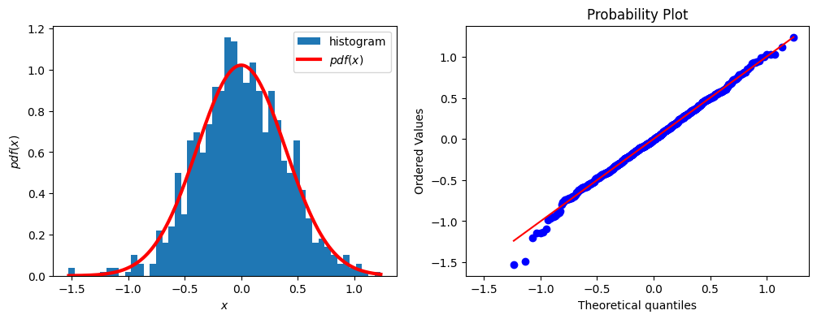

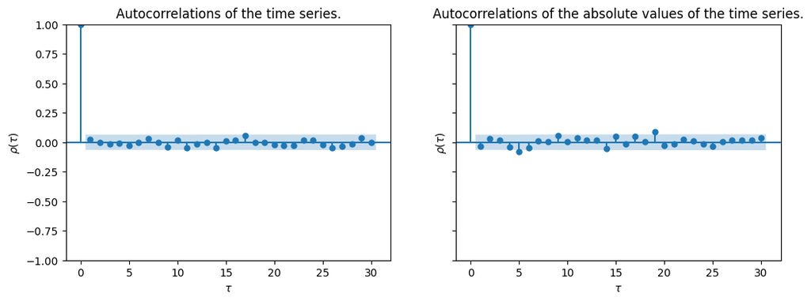

```python
# The residuals of the AR(p) model are Gaussian white noise.
u = residuals_AR(X, phi_0_ML, phi_ML)
tests_gaussian_white_noise(u)
```

### Exercise 1.3: Maximum likelihood fit to an AR model with Student's t distribution.

Assume that the noise follows a Student's t distribution of $\gamma$ degrees of freedom, centered at $0$, and with a scale parameter $\sigma$. $$ u_t \sim \text{t.pdf} \left(\gamma, 0, \sigma\right). $$ Note that, in this case, this scale parameter is not the standard deviation.

Design a function to fit an AR model with Student's t noise to the time series $\left(X_1, X_2, \ldots, X_T \right)$.

**The function should be implemented in the file `my_time_series.py`**.

References:

1. https://en.wikipedia.org/wiki/Student%27s_t-distribution
2. https://docs.scipy.org/doc/scipy/reference/generated/scipy.stats.t.html

```python
# Simulation of an AR(p) process with Student's t noise.

phi_0, phi, sigma, nu = 0.3, [0.1, -0.8], 0.4, 2.0
p = len(phi) # order of the autoregressive process.

def random_number_generator(size):
    return stats.t.rvs(df=nu, size = size, random_state=default_rng(seed=0))

X, _ = simulate_AR(
    np.zeros(p), phi_0, phi, sigma,
    random_number_generator, n_trajectories=1, n_times=2000
)

t_stationary = int(10.0 * t_transient(phi))

X = X[0, t_stationary:] # Single trajectory.
```

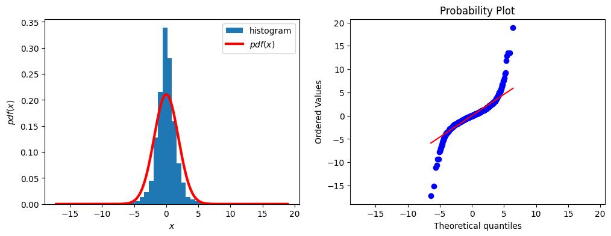

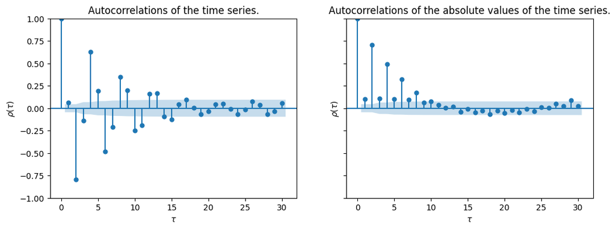

```python
# The distribution of the values of X_t is not Gaussian.
# It exhibits linear autocorrelations.

tests_gaussian_white_noise(X - np.mean(X))
```

#### Maximum likelihood fit to AR process with Student's t noise

```python
phi_0_ML, phi_ML, sigma_ML, nu_ML, info_optimization = fit_AR_ML_student_t_noise(
    X,
    phi_0_seed=0.0,
    phi_seed=np.zeros(2),
    sigma_seed=1.0,
    nu_seed=10.0,
)
```

```python
print('Exact:')
print(
    np.round(phi_0, 4),
    np.round(phi, 4),
    np.round(sigma, 4),
    np.round(nu, 4),
)

print('\nMaximum likelihood estimates:')
print(
    np.round(phi_0_ML, 4),
    np.round(phi_ML, 4),
    np.round(sigma_ML, 4),
    np.round(nu_ML, 4),
)

print()
print(info_optimization)
```

```
Exact:
0.3 [ 0.1 -0.8] 0.4 2.0

Maximum likelihood estimates:
0.1369 [0.0975] 1.058 2.8648

 message: Optimization terminated successfully
 success: True
  status: 0
     fun: 3528.3602124385798
       x: [ 1.369e-01  9.746e-02  1.058e+00  2.865e+00]
     nit: 12
     jac: [ 1.419e-02 -4.953e-02  5.219e-03 -2.625e-03]
    nfev: 78
    njev: 12
```

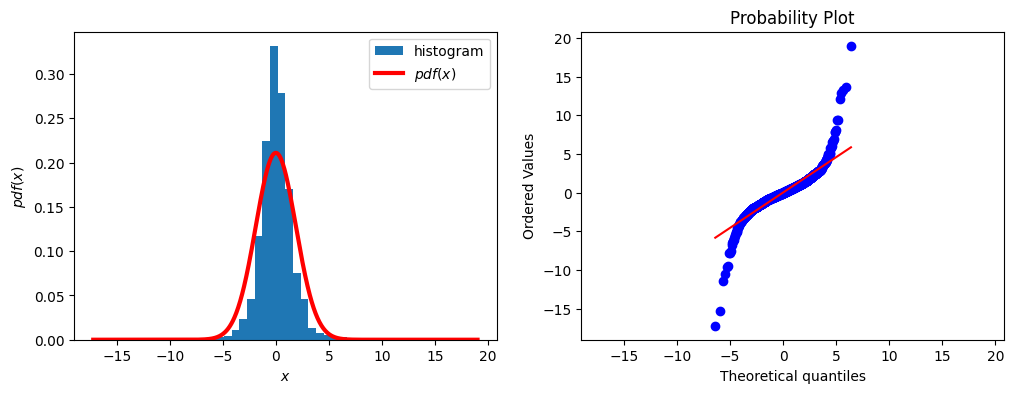

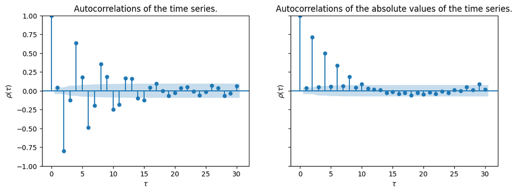

```python
# The residuals are not normally distributed
u = residuals_AR(X, phi_0_ML, phi_ML)
tests_gaussian_white_noise(u)
```

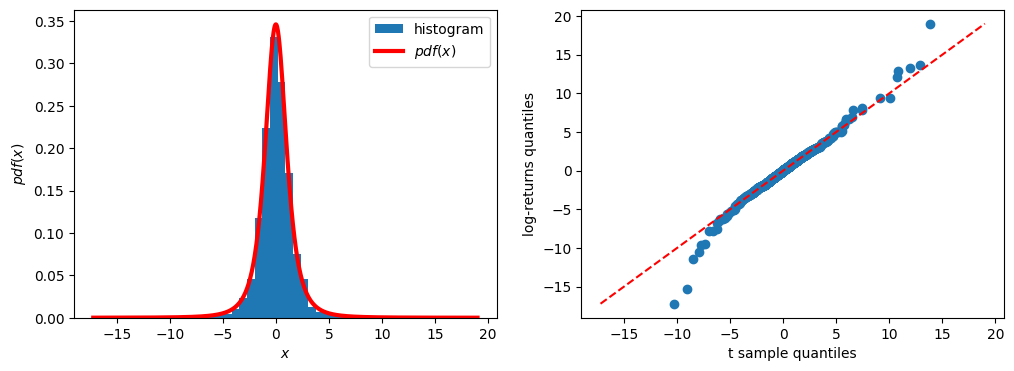

```python
# The residuals have a Student's t distribution.

fig, axs = plt.subplots(1, 2, figsize=(12, 4))

compare_histogram_pdf(
    u,
    lambda x: stats.t.pdf(x, nu_ML, 0.0, sigma_ML),
    n_bins=50,
    ax=axs[0]
)

rng = default_rng(seed=0)
reference_sample = stats.t.rvs(
    nu_ML, loc=0.0, scale=sigma_ML,
    size=(len(X)), random_state=rng
)

qqplot(reference_sample, u, ax=axs[1])
_ = axs[1].set_xlabel('t sample quantiles')
_ = axs[1].set_ylabel('log-returns quantiles')
# The Student's t distribution is very heavy-tailed.
# Therefore, it is normal that deviations appear at the tails in the qqplot.
```

## Exercise 2: AR(p) + GARCH(r,s) processes

The AR(p) + GARCH(r,s) process is given by the equations:

\begin{align*} X_t &= \phi_0 + \sum_{\tau=1}^p \phi_{\tau} X_{t- \tau} + u_t, \\ u_t &= \sqrt{h_t} \epsilon_t, \\ h_t &= \kappa + \sum_{\tau=1}^r \alpha_{\tau} u_{t- \tau}^2 + \sum_{\tau=1}^s \beta_{\tau} h_{t- \tau}. \end{align*}

where $\left\{\epsilon_t \right\}_{t=1}^{\max \left(p,r,s\right)}$ is independent identically distributed (iid) noise, which is also independent of $X_{t-\tau}$ for all $\tau > 0$.

To simulate this process, one needs to specify the initial conditions: $$\left\{X_t, u_t, h_t \right\}_{t=1}^{\max \left(p,r,s\right)}$$

### Maximum likelihood fit for an AR(p) + GARCH(r, s) process.

Assume that the distribution of the innovations is modeled by a probability density that, among others, has location and scale parameters: $$ u_t \sim \text{pdf}\left(u; loc=0.0, scale=\sqrt{h_t}, \boldsymbol{\gamma}\right). $$ The vector $\boldsymbol{\gamma}$ contains the parameters of the model distribution, other than the location and the scale.

Assume that we have a time series: $$ \left\{X_t \right\}_{t=1}^T = \left(X_1, X_2, \ldots, X_T \right). $$

For this model, the likelihood function to be optimized is: $$ \mathcal{L}\left(\phi_0, \boldsymbol{\phi}, \kappa, \boldsymbol{\alpha}, \boldsymbol{\beta},\boldsymbol{\gamma}; \left\{X_t \right\}_{t=1}^T \right) = \prod_{t=\max(p,r,s)+1}^T \text{pdf}\left(u_t; loc=0.0, scale=\sqrt{h_t}, \boldsymbol{\gamma} \right). $$

where

$$ u_t = X_t - \left(\phi_0 + \sum_{\tau=1}^p \phi_{\tau} X_{t- \tau} \right), \quad t > \max(p,r,s) $$

is independent of the past values of the series, and

$$ \epsilon_t = \frac{u_t}{\sqrt{h_t}}, \quad t > \max(p,r,s) $$

is iid noise.

```python
# Simulate AR(p) + GARCH(r,s)

phi_0, phi= 0.3, [0.1, 0.3]
p = len(phi) - 1
theta = []
q = len(theta)
kappa = 0.1
alpha = [0.27]
r = len(alpha)
beta = [0.70]
s = len(beta)
delay = max(p, q, r, s)
X_0 = np.ones(delay) * phi[0] / (1.0 - np.sum(phi[1:]))
u_0 = np.zeros(delay)
h_0 = np.ones(delay) * kappa / (1.0 - np.sum(alpha) - np.sum(beta))

random_number_generator = default_rng(seed=0).standard_normal

X, u, h = simulate_ARMA_GARCH(
    X_0, u_0, h_0,
    phi_0, phi, theta, kappa, alpha, beta,
    random_number_generator, n_trajectories=1, n_times=2000
)

t_transient = 100
X = X[0, t_transient:] # Single trajectory.
```

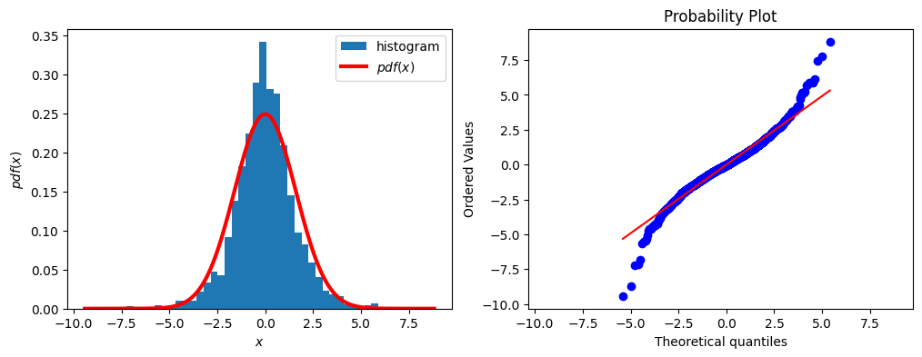

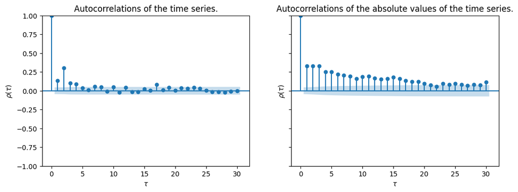

```python
# The distribution of the values of X_t is leptokurtic (heavy-tailed).
# It exhibits linear autocorrelations.

tests_gaussian_white_noise(X - np.mean(X))
```